# Group Project Oguz Colak

```r
library(tidyverse)
library(rvest)
library(ggplot2)
library(scales)
library(dplyr)
library(plyr)
library(data.table)
```

## Acquisition and Introduction of the Data

```r
# Temporary file for "Planning"
planning_temp=tempfile(fileext=".xlsx")
# Temporary file for "Production"
production_temp=tempfile(fileext=".xlsx")
# Temporary file for "Consumption"
consumption_temp=tempfile(fileext=".xlsx")

# Downloading file from repository to the "Planning" temp
download.file("https://raw.githubusercontent.com/pjournal/mef03g-Kar-R-sizlar/master/4-year-planning.csv?raw=true",destfile=planning_temp,mode='wb')
# Downloading file from repository to the "Production" temp
download.file("https://raw.githubusercontent.com/pjournal/mef03g-Kar-R-sizlar/master/4-year-production.csv?raw=true",destfile=production_temp,mode='wb')
# Downloading file from repository to the "Consumption" temp
download.file("https://raw.githubusercontent.com/pjournal/mef03g-Kar-R-sizlar/master/4-year-consumption.csv?raw=true",destfile=consumption_temp,mode='wb')

# Reading the csv files.
planning_raw_data=read.csv(planning_temp,skip=1)
production_raw_data=read.csv(production_temp,skip=1)
consumption_raw_data=read.csv(consumption_temp,skip=1)

# Removing the temp files
file.remove(planning_temp)
```

```
## [1] TRUE
```

```r
file.remove(production_temp)
```

```
## [1] TRUE
```

```r
file.remove(consumption_temp)
```

```
## [1] TRUE
```

### Preparation and Introduction of Planning Data

- 4 Year Planning Data: This data includes 33599 rows and 15 variables for the planned pruduction between January 1st, 2016 and October 31st, 2019

```r
# Proper Column Names
colnames(planning_raw_data) <-  c('tarih', 'saat', 'toplam_mwh', 'dogal_gaz', 'ruzgar', 'linyit', 'tas_komur', 'ithal_komur', 'fuel_oil', 'jeotermal', 'barajli', 'nafta', 'biyokutle', 'akarsu', 'diger')
# Proper Data Format
planning_raw_data[,3:15]  <- as.data.frame(lapply(planning_raw_data[,3:15], function(x) as.numeric(gsub(",", ".", gsub("\\.", "", x)))))
planning_raw_data$tarih <-as.character(planning_raw_data$tarih)
planning_raw_data$saat <-as.character(planning_raw_data$saat)
head(planning_raw_data, 5)
```

```
##        tarih  saat toplam_mwh dogal_gaz ruzgar  linyit tas_komur
## 1 01.01.2016 01:00   18735.09   5471.14 168.48 4139.53       736
## 2 01.01.2016 02:00   17662.05   5182.14 168.44 4139.53       736
## 3 01.01.2016 03:00   17059.91   5146.13 159.71 4139.53       736
## 4 01.01.2016 04:00   16903.33   4990.13 149.83 4139.53       736
## 5 01.01.2016 05:00   16845.48   4941.13 138.38 4139.53       736
##   ithal_komur fuel_oil jeotermal barajli nafta biyokutle akarsu diger
## 1        4587      115     104.1    3166     5         0 122.84   120
## 2        4470      115     104.1    2499     5         0 122.84   120
## 3        4470      115     104.1    1943     5         0 121.44   120
## 4        4470      115     104.1    1943     5         0 130.74   120
## 5        4470      115     104.1    1943     5         0 133.34   120
```

### Preparation and Introduction of Production Data

- 4 Year Production Data: This data includes 33597 rows and 18 variables for the actual pruduction between January 1st, 2016 and October 31st, 2019

```r
# Defining Column Names
colnames(production_raw_data) <-  c('tarih', 'saat', 'toplam_mwh', 'dogal_gaz', 'barajli', 'linyit', 'akarsu', 'ithal_komur', 'ruzgar', 'gunes', 'fuel_oil', 'jeotermal', 'asfaltit_komur', 'tas_komur', 'biyokutle', 'nafta', 'lng', 'uluslararasi')
# Proper Data Format
production_raw_data[,3:18]  <- as.data.frame(lapply(production_raw_data[,3:18], function(x) as.numeric(gsub(",", ".", gsub("\\.", "", x)))))
production_raw_data$tarih <-as.character(production_raw_data$tarih)
production_raw_data$saat <-as.character(production_raw_data$saat)

head(production_raw_data, 5)
```

```
##        tarih  saat toplam_mwh dogal_gaz barajli  linyit akarsu ithal_komur
## 1 01.01.2016 01:00   24491.99   6430.37 3604.49 4997.36 546.70     5269.60
## 2 01.01.2016 02:00   23109.42   5814.91 2865.77 5018.45 559.95     5165.70
## 3 01.01.2016 03:00   22037.52   5668.09 2156.75 4984.45 551.79     5148.64
## 4 01.01.2016 04:00   21527.40   5811.11 1665.71 4942.55 521.65     5123.66
## 5 01.01.2016 05:00   21560.19   5899.45 1809.77 4949.23 591.53     4917.75
##    ruzgar gunes fuel_oil jeotermal asfaltit_komur tas_komur biyokutle
## 1 2277.69     0    174.3    485.05          92.73     451.5    162.20
## 2 2278.95     0    176.1    485.97         128.06     455.5    160.06
## 3 2123.17     0    175.1    479.14         134.68     455.5    160.21
## 4 2057.80     0    177.2    466.16         136.89     462.5    162.17
## 5 1987.09     0    178.0    478.42         134.68     451.5    162.77
##   nafta lng uluslararasi
## 1     0   0            0
## 2     0   0            0
## 3     0   0            0
## 4     0   0            0
## 5     0   0            0
```

### Preparation and Introduction of Consumption Data

- 4 Year Consumpiton Data: This data includes 33575 rows and 3 variables for actual consumption between January 1st, 2016 and October 31st, 2019

```r
# Defining Column Names
colnames(consumption_raw_data) <-  c('tarih', 'saat', 'tuketim_miktari_mwh')
# Proper Data Format
consumption_raw_data <-  cbind(consumption_raw_data, consumption_raw_data)
consumption_raw_data[,3:6]  <- as.data.frame(lapply(consumption_raw_data[,3:6], function(x) as.numeric(gsub(",", ".", gsub("\\.", "", x)))))
consumption_raw_data <- consumption_raw_data[, 1:3]
consumption_raw_data$tarih <-as.character(consumption_raw_data$tarih)
consumption_raw_data$saat <-as.character(consumption_raw_data$saat)

head(consumption_raw_data, 5)
```

```
##        tarih  saat tuketim_miktari_mwh
## 1 01.01.2016 01:00            24991.82
## 2 01.01.2016 02:00            23532.61
## 3 01.01.2016 03:00            22464.78
## 4 01.01.2016 04:00            22002.91
## 5 01.01.2016 05:00            21957.08
```

## Creating Monthly Sums for Planning

```r
jan2016_planning_1 <- planning_raw_data %>% filter(grepl("01.2016", tarih))
jan_daily_2016_planning <- ddply(jan2016_planning_1,"tarih",numcolwise(sum))
January_2016_Planning <- colSums(Filter(is.numeric, jan2016_planning_1))
jan_monthly_2016_planning <- as.data.frame(January_2016_Planning)

feb2016_planning_1 <- planning_raw_data %>% filter(grepl("02.2016", tarih))
feb_daily_2016_planning <- ddply(feb2016_planning_1,"tarih",numcolwise(sum))
February_2016_Planning <- colSums(Filter(is.numeric, feb2016_planning_1))
feb_monthly_2016_planning <- as.data.frame(February_2016_Planning)

mar2016_planning_1 <- planning_raw_data %>% filter(grepl("03.2016", tarih))
mar_daily_2016_planning <- ddply(jan2016_planning_1,"tarih",numcolwise(sum))
March_2016_Planning <- colSums(Filter(is.numeric, mar2016_planning_1))
mar_monthly_2016_planning <- as.data.frame(March_2016_Planning)

apr2016_planning_1 <- planning_raw_data %>% filter(grepl("04.2016", tarih))
apr_daily_2016_planning <- ddply(apr2016_planning_1,"tarih",numcolwise(sum))
April_2016_Planning <- colSums(Filter(is.numeric, apr2016_planning_1))
apr_monthly_2016_planning <- as.data.frame(April_2016_Planning)

may2016_planning_1 <- planning_raw_data %>% filter(grepl("05.2016", tarih))
may_daily_2016_planning <- ddply(may2016_planning_1,"tarih",numcolwise(sum))
May_2016_Planning <- colSums(Filter(is.numeric, may2016_planning_1))
may_monthly_2016_planning <- as.data.frame(May_2016_Planning)

jun2016_planning_1 <- planning_raw_data %>% filter(grepl("06.2016", tarih))
jun_daily_2016_planning <- ddply(jun2016_planning_1,"tarih",numcolwise(sum))
June_2016_Planning <- colSums(Filter(is.numeric, jun2016_planning_1))
jun_monthly_2016_planning <- as.data.frame(June_2016_Planning)

jul2016_planning_1 <- planning_raw_data %>% filter(grepl("07.2016", tarih))
jul_daily_2016_planning <- ddply(jul2016_planning_1,"tarih",numcolwise(sum))
July_2016_Planning <- colSums(Filter(is.numeric, jul2016_planning_1))
jul_monthly_2016_planning <- as.data.frame(July_2016_Planning)

aug2016_planning_1 <- planning_raw_data %>% filter(grepl("08.2016", tarih))
aug_daily_2016_planning <- ddply(aug2016_planning_1,"tarih",numcolwise(sum))
August_2016_Planning <- colSums(Filter(is.numeric, aug2016_planning_1))
aug_monthly_2016_planning <- as.data.frame(August_2016_Planning)

sep2016_planning_1 <- planning_raw_data %>% filter(grepl("09.2016", tarih))
sep_daily_2016_planning <- ddply(sep2016_planning_1,"tarih",numcolwise(sum))
September_2016_Planning <- colSums(Filter(is.numeric, sep2016_planning_1))
sep_monthly_2016_planning <- as.data.frame(September_2016_Planning)

oct2016_planning_1 <- planning_raw_data %>% filter(grepl("10.2016", tarih))
oct_daily_2016_planning <- ddply(oct2016_planning_1,"tarih",numcolwise(sum))
October_2016_Planning <- colSums(Filter(is.numeric, oct2016_planning_1))
oct_monthly_2016_planning <- as.data.frame(October_2016_Planning)

nov2016_planning_1 <- planning_raw_data %>% filter(grepl("11.2016", tarih))
nov_daily_2016_planning <- ddply(nov2016_planning_1,"tarih",numcolwise(sum))
November_2016_Planning <- colSums(Filter(is.numeric, nov2016_planning_1))
nov_monthly_2016_planning <- as.data.frame(November_2016_Planning)

dec2016_planning_1 <- planning_raw_data %>% filter(grepl("12.2016", tarih))
dec_daily_2016_planning <- ddply(dec2016_planning_1,"tarih",numcolwise(sum))
December_2016_Planning <- colSums(Filter(is.numeric, dec2016_planning_1))
dec_monthly_2016_planning <- as.data.frame(December_2016_Planning)

Planning_2016_Monthly <- cbind(jan_monthly_2016_planning, feb_monthly_2016_planning, mar_monthly_2016_planning, apr_monthly_2016_planning, may_monthly_2016_planning, jun_monthly_2016_planning, jul_monthly_2016_planning, aug_monthly_2016_planning, sep_monthly_2016_planning, oct_monthly_2016_planning, nov_monthly_2016_planning, dec_monthly_2016_planning)

jan2017_planning_1 <- planning_raw_data %>% filter(grepl("01.2017", tarih))
jan_daily_2017_planning <- ddply(jan2017_planning_1,"tarih",numcolwise(sum))
January_2017_Planning <- colSums(Filter(is.numeric, jan2017_planning_1))
jan_monthly_2017_planning <- as.data.frame(January_2017_Planning)

feb2017_planning_1 <- planning_raw_data %>% filter(grepl("02.2017", tarih))
feb_daily_2017_planning <- ddply(feb2017_planning_1,"tarih",numcolwise(sum))
February_2017_Planning <- colSums(Filter(is.numeric, feb2017_planning_1))
feb_monthly_2017_planning <- as.data.frame(February_2017_Planning)

mar2017_planning_1 <- planning_raw_data %>% filter(grepl("03.2017", tarih))
mar_daily_2017_planning <- ddply(jan2017_planning_1,"tarih",numcolwise(sum))
March_2017_Planning <- colSums(Filter(is.numeric, mar2017_planning_1))
mar_monthly_2017_planning <- as.data.frame(March_2017_Planning)

apr2017_planning_1 <- planning_raw_data %>% filter(grepl("04.2017", tarih))
apr_daily_2017_planning <- ddply(apr2017_planning_1,"tarih",numcolwise(sum))
April_2017_Planning <- colSums(Filter(is.numeric, apr2017_planning_1))
apr_monthly_2017_planning <- as.data.frame(April_2017_Planning)

may2017_planning_1 <- planning_raw_data %>% filter(grepl("05.2017", tarih))
may_daily_2017_planning <- ddply(may2017_planning_1,"tarih",numcolwise(sum))
May_2017_Planning <- colSums(Filter(is.numeric, may2017_planning_1))
may_monthly_2017_planning <- as.data.frame(May_2017_Planning)

jun2017_planning_1 <- planning_raw_data %>% filter(grepl("06.2017", tarih))
jun_daily_2017_planning <- ddply(jun2017_planning_1,"tarih",numcolwise(sum))
June_2017_Planning <- colSums(Filter(is.numeric, jun2017_planning_1))
jun_monthly_2017_planning <- as.data.frame(June_2017_Planning)

jul2017_planning_1 <- planning_raw_data %>% filter(grepl("07.2017", tarih))
jul_daily_2017_planning <- ddply(jul2017_planning_1,"tarih",numcolwise(sum))
July_2017_Planning <- colSums(Filter(is.numeric, jul2017_planning_1))
jul_monthly_2017_planning <- as.data.frame(July_2017_Planning)

aug2017_planning_1 <- planning_raw_data %>% filter(grepl("08.2017", tarih))
aug_daily_2017_planning <- ddply(aug2017_planning_1,"tarih",numcolwise(sum))
August_2017_Planning <- colSums(Filter(is.numeric, aug2017_planning_1))
aug_monthly_2017_planning <- as.data.frame(August_2017_Planning)
```

```r
sep2017_planning_1 <- planning_raw_data %>% filter(grepl("09.2017", tarih))
sep_daily_2017_planning <- ddply(sep2017_planning_1,"tarih",numcolwise(sum))
September_2017_Planning <- colSums(Filter(is.numeric, sep2017_planning_1))
sep_monthly_2017_planning <- as.data.frame(September_2017_Planning)

oct2017_planning_1 <- planning_raw_data %>% filter(grepl("10.2017", tarih))
oct_daily_2017_planning <- ddply(oct2017_planning_1,"tarih",numcolwise(sum))
October_2017_Planning <- colSums(Filter(is.numeric, oct2017_planning_1))
oct_monthly_2017_planning <- as.data.frame(October_2017_Planning)

nov2017_planning_1 <- planning_raw_data %>% filter(grepl("11.2017", tarih))
nov_daily_2017_planning <- ddply(nov2017_planning_1,"tarih",numcolwise(sum))
November_2017_Planning <- colSums(Filter(is.numeric, nov2017_planning_1))
nov_monthly_2017_planning <- as.data.frame(November_2017_Planning)

dec2017_planning_1 <- planning_raw_data %>% filter(grepl("12.2017", tarih))
dec_daily_2017_planning <- ddply(dec2017_planning_1,"tarih",numcolwise(sum))
December_2017_Planning <- colSums(Filter(is.numeric, dec2017_planning_1))
dec_monthly_2017_planning <- as.data.frame(December_2017_Planning)

Planning_2017_Monthly <- cbind(jan_monthly_2017_planning, feb_monthly_2017_planning, mar_monthly_2017_planning, apr_monthly_2017_planning, may_monthly_2017_planning, jun_monthly_2017_planning, jul_monthly_2017_planning, aug_monthly_2017_planning, sep_monthly_2017_planning, oct_monthly_2017_planning, nov_monthly_2017_planning, dec_monthly_2017_planning)

jan2018_planning_1 <- planning_raw_data %>% filter(grepl("01.2018", tarih))
jan_daily_2018_planning <- ddply(jan2018_planning_1,"tarih",numcolwise(sum))
January_2018_Planning <- colSums(Filter(is.numeric, jan2018_planning_1))
jan_monthly_2018_planning <- as.data.frame(January_2018_Planning)

feb2018_planning_1 <- planning_raw_data %>% filter(grepl("02.2018", tarih))
feb_daily_2018_planning <- ddply(feb2018_planning_1,"tarih",numcolwise(sum))
February_2018_Planning <- colSums(Filter(is.numeric, feb2018_planning_1))
feb_monthly_2018_planning <- as.data.frame(February_2018_Planning)

mar2018_planning_1 <- planning_raw_data %>% filter(grepl("03.2018", tarih))
mar_daily_2018_planning <- ddply(jan2018_planning_1,"tarih",numcolwise(sum))
March_2018_Planning <- colSums(Filter(is.numeric, mar2018_planning_1))
mar_monthly_2018_planning <- as.data.frame(March_2018_Planning)

apr2018_planning_1 <- planning_raw_data %>% filter(grepl("04.2018", tarih))
apr_daily_2018_planning <- ddply(apr2018_planning_1,"tarih",numcolwise(sum))
April_2018_Planning <- colSums(Filter(is.numeric, apr2018_planning_1))
apr_monthly_2018_planning <- as.data.frame(April_2018_Planning)

may2018_planning_1 <- planning_raw_data %>% filter(grepl("05.2018", tarih))
may_daily_2018_planning <- ddply(may2018_planning_1,"tarih",numcolwise(sum))
May_2018_Planning <- colSums(Filter(is.numeric, may2018_planning_1))
may_monthly_2018_planning <- as.data.frame(May_2018_Planning)

jun2018_planning_1 <- planning_raw_data %>% filter(grepl("06.2018", tarih))
jun_daily_2018_planning <- ddply(jun2018_planning_1,"tarih",numcolwise(sum))
June_2018_Planning <- colSums(Filter(is.numeric, jun2018_planning_1))
jun_monthly_2018_planning <- as.data.frame(June_2018_Planning)

jul2018_planning_1 <- planning_raw_data %>% filter(grepl("07.2018", tarih))
jul_daily_2018_planning <- ddply(jul2018_planning_1,"tarih",numcolwise(sum))
July_2018_Planning <- colSums(Filter(is.numeric, jul2018_planning_1))
jul_monthly_2018_planning <- as.data.frame(July_2018_Planning)

aug2018_planning_1 <- planning_raw_data %>% filter(grepl("08.2018", tarih))
aug_daily_2018_planning <- ddply(aug2018_planning_1,"tarih",numcolwise(sum))
August_2018_Planning <- colSums(Filter(is.numeric, aug2018_planning_1))
aug_monthly_2018_planning <- as.data.frame(August_2018_Planning)

sep2018_planning_1 <- planning_raw_data %>% filter(grepl("09.2018", tarih))
sep_daily_2018_planning <- ddply(sep2018_planning_1,"tarih",numcolwise(sum))
September_2018_Planning <- colSums(Filter(is.numeric, sep2018_planning_1))
sep_monthly_2018_planning <- as.data.frame(September_2018_Planning)

oct2018_planning_1 <- planning_raw_data %>% filter(grepl("10.2018", tarih))
oct_daily_2018_planning <- ddply(oct2018_planning_1,"tarih",numcolwise(sum))
October_2018_Planning <- colSums(Filter(is.numeric, oct2018_planning_1))
oct_monthly_2018_planning <- as.data.frame(October_2018_Planning)

nov2018_planning_1 <- planning_raw_data %>% filter(grepl("11.2018", tarih))
nov_daily_2018_planning <- ddply(nov2018_planning_1,"tarih",numcolwise(sum))
November_2018_Planning <- colSums(Filter(is.numeric, nov2018_planning_1))
nov_monthly_2018_planning <- as.data.frame(November_2018_Planning)

dec2018_planning_1 <- planning_raw_data %>% filter(grepl("12.2018", tarih))
dec_daily_2018_planning <- ddply(dec2018_planning_1,"tarih",numcolwise(sum))
December_2018_Planning <- colSums(Filter(is.numeric, dec2018_planning_1))
dec_monthly_2018_planning <- as.data.frame(December_2018_Planning)

Planning_2018_Monthly <- cbind(jan_monthly_2018_planning, feb_monthly_2018_planning, mar_monthly_2018_planning, apr_monthly_2018_planning, may_monthly_2018_planning, jun_monthly_2018_planning, jul_monthly_2018_planning, aug_monthly_2018_planning, sep_monthly_2018_planning, oct_monthly_2018_planning, nov_monthly_2018_planning, dec_monthly_2018_planning)

jan2019_planning_1 <- planning_raw_data %>% filter(grepl("01.2019", tarih))
jan_daily_2019_planning <- ddply(jan2019_planning_1,"tarih",numcolwise(sum))
January_2019_Planning <- colSums(Filter(is.numeric, jan2019_planning_1))
jan_monthly_2019_planning <- as.data.frame(January_2019_Planning)

feb2019_planning_1 <- planning_raw_data %>% filter(grepl("02.2019", tarih))
feb_daily_2019_planning <- ddply(feb2019_planning_1,"tarih",numcolwise(sum))
February_2019_Planning <- colSums(Filter(is.numeric, feb2019_planning_1))
feb_monthly_2019_planning <- as.data.frame(February_2019_Planning)

mar2019_planning_1 <- planning_raw_data %>% filter(grepl("03.2019", tarih))
mar_daily_2019_planning <- ddply(jan2019_planning_1,"tarih",numcolwise(sum))
March_2019_Planning <- colSums(Filter(is.numeric, mar2019_planning_1))
mar_monthly_2019_planning <- as.data.frame(March_2019_Planning)
```

```r
apr2019_planning_1 <- planning_raw_data %>% filter(grepl("04.2019", tarih))
apr_daily_2019_planning <- ddply(apr2019_planning_1,"tarih",numcolwise(sum))
April_2019_Planning <- colSums(Filter(is.numeric, apr2019_planning_1))
apr_monthly_2019_planning <- as.data.frame(April_2019_Planning)

may2019_planning_1 <- planning_raw_data %>% filter(grepl("05.2019", tarih))
may_daily_2019_planning <- ddply(may2019_planning_1,"tarih",numcolwise(sum))
May_2019_Planning <- colSums(Filter(is.numeric, may2019_planning_1))
may_monthly_2019_planning <- as.data.frame(May_2019_Planning)

jun2019_planning_1 <- planning_raw_data %>% filter(grepl("06.2019", tarih))
jun_daily_2019_planning <- ddply(jun2019_planning_1,"tarih",numcolwise(sum))
June_2019_Planning <- colSums(Filter(is.numeric, jun2019_planning_1))
jun_monthly_2019_planning <- as.data.frame(June_2019_Planning)

jul2019_planning_1 <- planning_raw_data %>% filter(grepl("07.2019", tarih))
jul_daily_2019_planning <- ddply(jul2019_planning_1,"tarih",numcolwise(sum))
July_2019_Planning <- colSums(Filter(is.numeric, jul2019_planning_1))
jul_monthly_2019_planning <- as.data.frame(July_2019_Planning)

aug2019_planning_1 <- planning_raw_data %>% filter(grepl("08.2019", tarih))
aug_daily_2019_planning <- ddply(aug2019_planning_1,"tarih",numcolwise(sum))
August_2019_Planning <- colSums(Filter(is.numeric, aug2019_planning_1))
aug_monthly_2019_planning <- as.data.frame(August_2019_Planning)

sep2019_planning_1 <- planning_raw_data %>% filter(grepl("09.2019", tarih))
sep_daily_2019_planning <- ddply(sep2019_planning_1,"tarih",numcolwise(sum))
September_2019_Planning <- colSums(Filter(is.numeric, sep2019_planning_1))
sep_monthly_2019_planning <- as.data.frame(September_2019_Planning)

oct2019_planning_1 <- planning_raw_data %>% filter(grepl("10.2019", tarih))
oct_daily_2019_planning <- ddply(oct2019_planning_1,"tarih",numcolwise(sum))
October_2019_Planning <- colSums(Filter(is.numeric, oct2019_planning_1))
oct_monthly_2019_planning <- as.data.frame(October_2019_Planning)

Planning_2019_Monthly <- cbind(jan_monthly_2019_planning, feb_monthly_2019_planning, mar_monthly_2019_planning, apr_monthly_2019_planning, may_monthly_2019_planning, jun_monthly_2019_planning, jul_monthly_2019_planning, aug_monthly_2019_planning, sep_monthly_2019_planning, oct_monthly_2019_planning)

Planning_Monthly <- cbind(Planning_2016_Monthly, Planning_2017_Monthly, Planning_2018_Monthly, Planning_2019_Monthly)
Planning_Monthly <- rownames_to_column(Planning_Monthly, var = "Sources")

head(Planning_Monthly, 5)
```

```
##      Sources January_2016_Planning February_2016_Planning
## 1 toplam_mwh           18385705.14             16370337.6
## 2  dogal_gaz            6956584.34              5751946.6
## 3     ruzgar              97156.52               125460.9
## 4     linyit            2785761.43              2562704.7
## 5  tas_komur             553672.00               530251.0
##   March_2016_Planning April_2016_Planning May_2016_Planning
## 1          18588230.5          18356082.7        19877152.8
## 2           5427182.0           6086039.2         5080386.8
## 3            618063.5            487208.6          705477.8
## 4           2419856.9           1794657.9         2189355.6
## 5            630380.0            554156.0          575697.0
##   June_2016_Planning July_2016_Planning August_2016_Planning
## 1         20746099.8           21956748           23643419.4
## 2          6095654.4            7078596            8823670.8
```

[output cut: 81 more lines]

## Creating Monthly Sums for Production

```r
jan2016_production_1 <- production_raw_data %>% filter(grepl("01.2016", tarih))
jan_daily_2016_production <- ddply(jan2016_production_1,"tarih",numcolwise(sum))
January_2016_Production <- colSums(Filter(is.numeric, jan2016_production_1))
jan_monthly_2016_production <- as.data.frame(January_2016_Production)

feb2016_production_1 <- production_raw_data %>% filter(grepl("02.2016", tarih))
feb_daily_2016_production <- ddply(feb2016_production_1,"tarih",numcolwise(sum))
February_2016_Production <- colSums(Filter(is.numeric, feb2016_production_1))
feb_monthly_2016_production <- as.data.frame(February_2016_Production)

mar2016_production_1 <- production_raw_data %>% filter(grepl("03.2016", tarih))
mar_daily_2016_production <- ddply(jan2016_production_1,"tarih",numcolwise(sum))
March_2016_Production <- colSums(Filter(is.numeric, mar2016_production_1))
mar_monthly_2016_production <- as.data.frame(March_2016_Production)

apr2016_production_1 <- production_raw_data %>% filter(grepl("04.2016", tarih))
apr_daily_2016_production <- ddply(apr2016_production_1,"tarih",numcolwise(sum))
April_2016_Production <- colSums(Filter(is.numeric, apr2016_production_1))
apr_monthly_2016_production <- as.data.frame(April_2016_Production)

may2016_production_1 <- production_raw_data %>% filter(grepl("05.2016", tarih))
may_daily_2016_production <- ddply(may2016_production_1,"tarih",numcolwise(sum))
May_2016_Production <- colSums(Filter(is.numeric, may2016_production_1))
may_monthly_2016_production <- as.data.frame(May_2016_Production)

jun2016_production_1 <- production_raw_data %>% filter(grepl("06.2016", tarih))
jun_daily_2016_production <- ddply(jun2016_production_1,"tarih",numcolwise(sum))
June_2016_Production <- colSums(Filter(is.numeric, jun2016_production_1))
jun_monthly_2016_production <- as.data.frame(June_2016_Production)

jul2016_production_1 <- production_raw_data %>% filter(grepl("07.2016", tarih))
jul_daily_2016_production <- ddply(jul2016_production_1,"tarih",numcolwise(sum))
July_2016_Production <- colSums(Filter(is.numeric, jul2016_production_1))
jul_monthly_2016_production <- as.data.frame(July_2016_Production)

aug2016_production_1 <- production_raw_data %>% filter(grepl("08.2016", tarih))
aug_daily_2016_production <- ddply(aug2016_production_1,"tarih",numcolwise(sum))
August_2016_Production <- colSums(Filter(is.numeric, aug2016_production_1))
aug_monthly_2016_production <- as.data.frame(August_2016_Production)

sep2016_production_1 <- production_raw_data %>% filter(grepl("09.2016", tarih))
sep_daily_2016_production <- ddply(sep2016_production_1,"tarih",numcolwise(sum))
September_2016_Production <- colSums(Filter(is.numeric, sep2016_production_1))
sep_monthly_2016_production <- as.data.frame(September_2016_Production)

oct2016_production_1 <- production_raw_data %>% filter(grepl("10.2016", tarih))
oct_daily_2016_production <- ddply(oct2016_production_1,"tarih",numcolwise(sum))
October_2016_Production <- colSums(Filter(is.numeric, oct2016_production_1))
oct_monthly_2016_production <- as.data.frame(October_2016_Production)

nov2016_production_1 <- production_raw_data %>% filter(grepl("11.2016", tarih))
nov_daily_2016_production <- ddply(nov2016_production_1,"tarih",numcolwise(sum))
November_2016_Production <- colSums(Filter(is.numeric, nov2016_production_1))
nov_monthly_2016_production <- as.data.frame(November_2016_Production)

dec2016_production_1 <- production_raw_data %>% filter(grepl("12.2016", tarih))
dec_daily_2016_production <- ddply(dec2016_production_1,"tarih",numcolwise(sum))
December_2016_Production <- colSums(Filter(is.numeric, dec2016_production_1))
dec_monthly_2016_production <- as.data.frame(December_2016_Production)

Production_2016_Monthly <- cbind(jan_monthly_2016_production, feb_monthly_2016_production, mar_monthly_2016_production, apr_monthly_2016_production, may_monthly_2016_production, jun_monthly_2016_production, jul_monthly_2016_production, aug_monthly_2016_production, sep_monthly_2016_production, oct_monthly_2016_production, nov_monthly_2016_production, dec_monthly_2016_production)

jan2017_production_1 <- production_raw_data %>% filter(grepl("01.2017", tarih))
jan_daily_2017_production <- ddply(jan2017_production_1,"tarih",numcolwise(sum))
January_2017_Production <- colSums(Filter(is.numeric, jan2017_production_1))
jan_monthly_2017_production <- as.data.frame(January_2017_Production)

feb2017_production_1 <- production_raw_data %>% filter(grepl("02.2017", tarih))
feb_daily_2017_production <- ddply(feb2017_production_1,"tarih",numcolwise(sum))
February_2017_Production <- colSums(Filter(is.numeric, feb2017_production_1))
feb_monthly_2017_production <- as.data.frame(February_2017_Production)

mar2017_production_1 <- production_raw_data %>% filter(grepl("03.2017", tarih))
mar_daily_2017_production <- ddply(jan2017_production_1,"tarih",numcolwise(sum))
March_2017_Production <- colSums(Filter(is.numeric, mar2017_production_1))
mar_monthly_2017_production <- as.data.frame(March_2017_Production)

apr2017_production_1 <- production_raw_data %>% filter(grepl("04.2017", tarih))
apr_daily_2017_production <- ddply(apr2017_production_1,"tarih",numcolwise(sum))
April_2017_Production <- colSums(Filter(is.numeric, apr2017_production_1))
apr_monthly_2017_production <- as.data.frame(April_2017_Production)

may2017_production_1 <- production_raw_data %>% filter(grepl("05.2017", tarih))
may_daily_2017_production <- ddply(may2017_production_1,"tarih",numcolwise(sum))
May_2017_Production <- colSums(Filter(is.numeric, may2017_production_1))
may_monthly_2017_production <- as.data.frame(May_2017_Production)

jun2017_production_1 <- production_raw_data %>% filter(grepl("06.2017", tarih))
jun_daily_2017_production <- ddply(jun2017_production_1,"tarih",numcolwise(sum))
June_2017_Production <- colSums(Filter(is.numeric, jun2017_production_1))
jun_monthly_2017_production <- as.data.frame(June_2017_Production)

jul2017_production_1 <- production_raw_data %>% filter(grepl("07.2017", tarih))
jul_daily_2017_production <- ddply(jul2017_production_1,"tarih",numcolwise(sum))
July_2017_Production <- colSums(Filter(is.numeric, jul2017_production_1))
jul_monthly_2017_production <- as.data.frame(July_2017_Production)
```

```r
aug2017_production_1 <- production_raw_data %>% filter(grepl("08.2017", tarih))
aug_daily_2017_production <- ddply(aug2017_production_1,"tarih",numcolwise(sum))
August_2017_Production <- colSums(Filter(is.numeric, aug2017_production_1))
aug_monthly_2017_production <- as.data.frame(August_2017_Production)

sep2017_production_1 <- production_raw_data %>% filter(grepl("09.2017", tarih))
sep_daily_2017_production <- ddply(sep2017_production_1,"tarih",numcolwise(sum))
September_2017_Production <- colSums(Filter(is.numeric, sep2017_production_1))
sep_monthly_2017_production <- as.data.frame(September_2017_Production)

oct2017_production_1 <- production_raw_data %>% filter(grepl("10.2017", tarih))
oct_daily_2017_production <- ddply(oct2017_production_1,"tarih",numcolwise(sum))
October_2017_Production <- colSums(Filter(is.numeric, oct2017_production_1))
oct_monthly_2017_production <- as.data.frame(October_2017_Production)

nov2017_production_1 <- production_raw_data %>% filter(grepl("11.2017", tarih))
nov_daily_2017_production <- ddply(nov2017_production_1,"tarih",numcolwise(sum))
November_2017_Production <- colSums(Filter(is.numeric, nov2017_production_1))
nov_monthly_2017_production <- as.data.frame(November_2017_Production)

dec2017_production_1 <- production_raw_data %>% filter(grepl("12.2017", tarih))
dec_daily_2017_production <- ddply(dec2017_production_1,"tarih",numcolwise(sum))
December_2017_Production <- colSums(Filter(is.numeric, dec2017_production_1))
dec_monthly_2017_production <- as.data.frame(December_2017_Production)

Production_2017_Monthly <- cbind(jan_monthly_2017_production, feb_monthly_2017_production, mar_monthly_2017_production, apr_monthly_2017_production, may_monthly_2017_production, jun_monthly_2017_production, jul_monthly_2017_production, aug_monthly_2017_production, sep_monthly_2017_production, oct_monthly_2017_production, nov_monthly_2017_production, dec_monthly_2017_production)

jan2018_production_1 <- production_raw_data %>% filter(grepl("01.2018", tarih))
jan_daily_2018_production <- ddply(jan2018_production_1,"tarih",numcolwise(sum))
January_2018_Production <- colSums(Filter(is.numeric, jan2018_production_1))
jan_monthly_2018_production <- as.data.frame(January_2018_Production)

feb2018_production_1 <- production_raw_data %>% filter(grepl("02.2018", tarih))
feb_daily_2018_production <- ddply(feb2018_production_1,"tarih",numcolwise(sum))
February_2018_Production <- colSums(Filter(is.numeric, feb2018_production_1))
feb_monthly_2018_production <- as.data.frame(February_2018_Production)

mar2018_production_1 <- production_raw_data %>% filter(grepl("03.2018", tarih))
mar_daily_2018_production <- ddply(jan2018_production_1,"tarih",numcolwise(sum))
March_2018_Production <- colSums(Filter(is.numeric, mar2018_production_1))
mar_monthly_2018_production <- as.data.frame(March_2018_Production)

apr2018_production_1 <- production_raw_data %>% filter(grepl("04.2018", tarih))
apr_daily_2018_production <- ddply(apr2018_production_1,"tarih",numcolwise(sum))
April_2018_Production <- colSums(Filter(is.numeric, apr2018_production_1))
apr_monthly_2018_production <- as.data.frame(April_2018_Production)

may2018_production_1 <- production_raw_data %>% filter(grepl("05.2018", tarih))
may_daily_2018_production <- ddply(may2018_production_1,"tarih",numcolwise(sum))
May_2018_Production <- colSums(Filter(is.numeric, may2018_production_1))
may_monthly_2018_production <- as.data.frame(May_2018_Production)

jun2018_production_1 <- production_raw_data %>% filter(grepl("06.2018", tarih))
jun_daily_2018_production <- ddply(jun2018_production_1,"tarih",numcolwise(sum))
June_2018_Production <- colSums(Filter(is.numeric, jun2018_production_1))
jun_monthly_2018_production <- as.data.frame(June_2018_Production)

jul2018_production_1 <- production_raw_data %>% filter(grepl("07.2018", tarih))
jul_daily_2018_production <- ddply(jul2018_production_1,"tarih",numcolwise(sum))
July_2018_Production <- colSums(Filter(is.numeric, jul2018_production_1))
jul_monthly_2018_production <- as.data.frame(July_2018_Production)

aug2018_production_1 <- production_raw_data %>% filter(grepl("08.2018", tarih))
aug_daily_2018_production <- ddply(aug2018_production_1,"tarih",numcolwise(sum))
August_2018_Production <- colSums(Filter(is.numeric, aug2018_production_1))
aug_monthly_2018_production <- as.data.frame(August_2018_Production)

sep2018_production_1 <- production_raw_data %>% filter(grepl("09.2018", tarih))
sep_daily_2018_production <- ddply(sep2018_production_1,"tarih",numcolwise(sum))
September_2018_Production <- colSums(Filter(is.numeric, sep2018_production_1))
sep_monthly_2018_production <- as.data.frame(September_2018_Production)

oct2018_production_1 <- production_raw_data %>% filter(grepl("10.2018", tarih))
oct_daily_2018_production <- ddply(oct2018_production_1,"tarih",numcolwise(sum))
October_2018_Production <- colSums(Filter(is.numeric, oct2018_production_1))
oct_monthly_2018_production <- as.data.frame(October_2018_Production)

nov2018_production_1 <- production_raw_data %>% filter(grepl("11.2018", tarih))
nov_daily_2018_production <- ddply(nov2018_production_1,"tarih",numcolwise(sum))
November_2018_Production <- colSums(Filter(is.numeric, nov2018_production_1))
nov_monthly_2018_production <- as.data.frame(November_2018_Production)

dec2018_production_1 <- production_raw_data %>% filter(grepl("12.2018", tarih))
dec_daily_2018_production <- ddply(dec2018_production_1,"tarih",numcolwise(sum))
December_2018_Production <- colSums(Filter(is.numeric, dec2018_production_1))
dec_monthly_2018_production <- as.data.frame(December_2018_Production)

Production_2018_Monthly <- cbind(jan_monthly_2018_production, feb_monthly_2018_production, mar_monthly_2018_production, apr_monthly_2018_production, may_monthly_2018_production, jun_monthly_2018_production, jul_monthly_2018_production, aug_monthly_2018_production, sep_monthly_2018_production, oct_monthly_2018_production, nov_monthly_2018_production, dec_monthly_2018_production)
```

```r
jan2019_production_1 <- production_raw_data %>% filter(grepl("01.2019", tarih))
jan_daily_2019_production <- ddply(jan2019_production_1,"tarih",numcolwise(sum))
January_2019_Production <- colSums(Filter(is.numeric, jan2019_production_1))
jan_monthly_2019_production <- as.data.frame(January_2019_Production)

feb2019_production_1 <- production_raw_data %>% filter(grepl("02.2019", tarih))
feb_daily_2019_production <- ddply(feb2019_production_1,"tarih",numcolwise(sum))
February_2019_Production <- colSums(Filter(is.numeric, feb2019_production_1))
feb_monthly_2019_production <- as.data.frame(February_2019_Production)

mar2019_production_1 <- production_raw_data %>% filter(grepl("03.2019", tarih))
mar_daily_2019_production <- ddply(jan2019_production_1,"tarih",numcolwise(sum))
March_2019_Production <- colSums(Filter(is.numeric, mar2019_production_1))
mar_monthly_2019_production <- as.data.frame(March_2019_Production)

apr2019_production_1 <- production_raw_data %>% filter(grepl("04.2019", tarih))
apr_daily_2019_production <- ddply(apr2019_production_1,"tarih",numcolwise(sum))
April_2019_Production <- colSums(Filter(is.numeric, apr2019_production_1))
apr_monthly_2019_production <- as.data.frame(April_2019_Production)

may2019_production_1 <- production_raw_data %>% filter(grepl("05.2019", tarih))
may_daily_2019_production <- ddply(may2019_production_1,"tarih",numcolwise(sum))
May_2019_Production <- colSums(Filter(is.numeric, may2019_production_1))
may_monthly_2019_production <- as.data.frame(May_2019_Production)

jun2019_production_1 <- production_raw_data %>% filter(grepl("06.2019", tarih))
jun_daily_2019_production <- ddply(jun2019_production_1,"tarih",numcolwise(sum))
June_2019_Production <- colSums(Filter(is.numeric, jun2019_production_1))
jun_monthly_2019_production <- as.data.frame(June_2019_Production)

jul2019_production_1 <- production_raw_data %>% filter(grepl("07.2019", tarih))
jul_daily_2019_production <- ddply(jul2019_production_1,"tarih",numcolwise(sum))
July_2019_Production <- colSums(Filter(is.numeric, jul2019_production_1))
jul_monthly_2019_production <- as.data.frame(July_2019_Production)

aug2019_production_1 <- production_raw_data %>% filter(grepl("08.2019", tarih))
aug_daily_2019_production <- ddply(aug2019_production_1,"tarih",numcolwise(sum))
August_2019_Production <- colSums(Filter(is.numeric, aug2019_production_1))
aug_monthly_2019_production <- as.data.frame(August_2019_Production)

sep2019_production_1 <- production_raw_data %>% filter(grepl("09.2019", tarih))
sep_daily_2019_production <- ddply(sep2019_production_1,"tarih",numcolwise(sum))
September_2019_Production <- colSums(Filter(is.numeric, sep2019_production_1))
sep_monthly_2019_production <- as.data.frame(September_2019_Production)

oct2019_production_1 <- production_raw_data %>% filter(grepl("10.2019", tarih))
oct_daily_2019_production <- ddply(oct2019_production_1,"tarih",numcolwise(sum))
October_2019_Production <- colSums(Filter(is.numeric, oct2019_production_1))
oct_monthly_2019_production <- as.data.frame(October_2019_Production)

Production_2019_Monthly <- cbind(jan_monthly_2019_production, feb_monthly_2019_production, mar_monthly_2019_production, apr_monthly_2019_production, may_monthly_2019_production, jun_monthly_2019_production, jul_monthly_2019_production, aug_monthly_2019_production, sep_monthly_2019_production, oct_monthly_2019_production)

Production_Monthly <- cbind(Production_2016_Monthly, Production_2017_Monthly, Production_2018_Monthly, Production_2019_Monthly)
Production_Monthly <- rownames_to_column(Production_Monthly, var = "Sources")

head(Production_Monthly, 5)
```

```
##      Sources January_2016_Production February_2016_Production
## 1 toplam_mwh                23155072                 20639380
## 2  dogal_gaz                 8093942                  6851969
## 3    barajli                 4249679                  3283233
## 4     linyit                 3401925                  3112894
## 5     akarsu                 1271297                  1815672
##   March_2016_Production April_2016_Production May_2016_Production
## 1              21718680              20962513            21523232
## 2               6278424               6733069             6033318
## 3               4260896               4288169             4077205
## 4               3066094               2359898             2775400
## 5               2480136               2680860             2578332
##   June_2016_Production July_2016_Production August_2016_Production
## 1             22565419             23822010             25665544.7
## 2              7220660              7791337              9391728.4
```

[output cut: 93 more lines]

## Creating Monthly Sums for Consumption

```r
jan2016_consumption_1 <- consumption_raw_data %>% filter(grepl("01.2016", tarih))
jan_daily_2016_consumption <- ddply(jan2016_consumption_1,"tarih",numcolwise(sum))
January_2016_Consumption <- colSums(Filter(is.numeric, jan2016_consumption_1))
jan_monthly_2016_consumption <- as.data.frame(January_2016_Consumption)

feb2016_consumption_1 <- consumption_raw_data %>% filter(grepl("02.2016", tarih))
feb_daily_2016_consumption <- ddply(feb2016_consumption_1,"tarih",numcolwise(sum))
February_2016_Consumption <- colSums(Filter(is.numeric, feb2016_consumption_1))
feb_monthly_2016_consumption <- as.data.frame(February_2016_Consumption)

mar2016_consumption_1 <- consumption_raw_data %>% filter(grepl("03.2016", tarih))
mar_daily_2016_consumption <- ddply(jan2016_consumption_1,"tarih",numcolwise(sum))
March_2016_Consumption <- colSums(Filter(is.numeric, mar2016_consumption_1))
mar_monthly_2016_consumption <- as.data.frame(March_2016_Consumption)

apr2016_consumption_1 <- consumption_raw_data %>% filter(grepl("04.2016", tarih))
apr_daily_2016_consumption <- ddply(apr2016_consumption_1,"tarih",numcolwise(sum))
April_2016_Consumption <- colSums(Filter(is.numeric, apr2016_consumption_1))
apr_monthly_2016_consumption <- as.data.frame(April_2016_Consumption)

may2016_consumption_1 <- consumption_raw_data %>% filter(grepl("05.2016", tarih))
may_daily_2016_consumption <- ddply(may2016_consumption_1,"tarih",numcolwise(sum))
May_2016_Consumption <- colSums(Filter(is.numeric, may2016_consumption_1))
may_monthly_2016_consumption <- as.data.frame(May_2016_Consumption)

jun2016_consumption_1 <- consumption_raw_data %>% filter(grepl("06.2016", tarih))
jun_daily_2016_consumption <- ddply(jun2016_consumption_1,"tarih",numcolwise(sum))
June_2016_Consumption <- colSums(Filter(is.numeric, jun2016_consumption_1))
jun_monthly_2016_consumption <- as.data.frame(June_2016_Consumption)

jul2016_consumption_1 <- consumption_raw_data %>% filter(grepl("07.2016", tarih))
jul_daily_2016_consumption <- ddply(jul2016_consumption_1,"tarih",numcolwise(sum))
July_2016_Consumption <- colSums(Filter(is.numeric, jul2016_consumption_1))
jul_monthly_2016_consumption <- as.data.frame(July_2016_Consumption)

aug2016_consumption_1 <- consumption_raw_data %>% filter(grepl("08.2016", tarih))
aug_daily_2016_consumption <- ddply(aug2016_consumption_1,"tarih",numcolwise(sum))
August_2016_Consumption <- colSums(Filter(is.numeric, aug2016_consumption_1))
aug_monthly_2016_consumption <- as.data.frame(August_2016_Consumption)

sep2016_consumption_1 <- consumption_raw_data %>% filter(grepl("09.2016", tarih))
sep_daily_2016_consumption <- ddply(sep2016_consumption_1,"tarih",numcolwise(sum))
September_2016_Consumption <- colSums(Filter(is.numeric, sep2016_consumption_1))
sep_monthly_2016_consumption <- as.data.frame(September_2016_Consumption)

oct2016_consumption_1 <- consumption_raw_data %>% filter(grepl("10.2016", tarih))
oct_daily_2016_consumption <- ddply(oct2016_consumption_1,"tarih",numcolwise(sum))
October_2016_Consumption <- colSums(Filter(is.numeric, oct2016_consumption_1))
oct_monthly_2016_consumption <- as.data.frame(October_2016_Consumption)

nov2016_consumption_1 <- consumption_raw_data %>% filter(grepl("11.2016", tarih))
nov_daily_2016_consumption <- ddply(nov2016_consumption_1,"tarih",numcolwise(sum))
November_2016_Consumption <- colSums(Filter(is.numeric, nov2016_consumption_1))
nov_monthly_2016_consumption <- as.data.frame(November_2016_Consumption)

dec2016_consumption_1 <- consumption_raw_data %>% filter(grepl("12.2016", tarih))
dec_daily_2016_consumption <- ddply(dec2016_consumption_1,"tarih",numcolwise(sum))
December_2016_Consumption <- colSums(Filter(is.numeric, dec2016_consumption_1))
dec_monthly_2016_consumption <- as.data.frame(December_2016_Consumption)

Consumption_2016_Monthly <- cbind(jan_monthly_2016_consumption, feb_monthly_2016_consumption, mar_monthly_2016_consumption, apr_monthly_2016_consumption, may_monthly_2016_consumption, jun_monthly_2016_consumption, jul_monthly_2016_consumption, aug_monthly_2016_consumption, sep_monthly_2016_consumption, oct_monthly_2016_consumption, nov_monthly_2016_consumption, dec_monthly_2016_consumption)

jan2017_consumption_1 <- consumption_raw_data %>% filter(grepl("01.2017", tarih))
jan_daily_2017_consumption <- ddply(jan2017_consumption_1,"tarih",numcolwise(sum))
January_2017_Consumption <- colSums(Filter(is.numeric, jan2017_consumption_1))
jan_monthly_2017_consumption <- as.data.frame(January_2017_Consumption)

feb2017_consumption_1 <- consumption_raw_data %>% filter(grepl("02.2017", tarih))
feb_daily_2017_consumption <- ddply(feb2017_consumption_1,"tarih",numcolwise(sum))
February_2017_Consumption <- colSums(Filter(is.numeric, feb2017_consumption_1))
feb_monthly_2017_consumption <- as.data.frame(February_2017_Consumption)

mar2017_consumption_1 <- consumption_raw_data %>% filter(grepl("03.2017", tarih))
mar_daily_2017_consumption <- ddply(jan2017_consumption_1,"tarih",numcolwise(sum))
March_2017_Consumption <- colSums(Filter(is.numeric, mar2017_consumption_1))
mar_monthly_2017_consumption <- as.data.frame(March_2017_Consumption)

apr2017_consumption_1 <- consumption_raw_data %>% filter(grepl("04.2017", tarih))
apr_daily_2017_consumption <- ddply(apr2017_consumption_1,"tarih",numcolwise(sum))
April_2017_Consumption <- colSums(Filter(is.numeric, apr2017_consumption_1))
apr_monthly_2017_consumption <- as.data.frame(April_2017_Consumption)

may2017_consumption_1 <- consumption_raw_data %>% filter(grepl("05.2017", tarih))
may_daily_2017_consumption <- ddply(may2017_consumption_1,"tarih",numcolwise(sum))
May_2017_Consumption <- colSums(Filter(is.numeric, may2017_consumption_1))
may_monthly_2017_consumption <- as.data.frame(May_2017_Consumption)

jun2017_consumption_1 <- consumption_raw_data %>% filter(grepl("06.2017", tarih))
jun_daily_2017_consumption <- ddply(jun2017_consumption_1,"tarih",numcolwise(sum))
June_2017_Consumption <- colSums(Filter(is.numeric, jun2017_consumption_1))
jun_monthly_2017_consumption <- as.data.frame(June_2017_Consumption)
```

```r
jul2017_consumption_1 <- consumption_raw_data %>% filter(grepl("07.2017", tarih))
jul_daily_2017_consumption <- ddply(jul2017_consumption_1,"tarih",numcolwise(sum))
July_2017_Consumption <- colSums(Filter(is.numeric, jul2017_consumption_1))
jul_monthly_2017_consumption <- as.data.frame(July_2017_Consumption)

aug2017_consumption_1 <- consumption_raw_data %>% filter(grepl("08.2017", tarih))
aug_daily_2017_consumption <- ddply(aug2017_consumption_1,"tarih",numcolwise(sum))
August_2017_Consumption <- colSums(Filter(is.numeric, aug2017_consumption_1))
aug_monthly_2017_consumption <- as.data.frame(August_2017_Consumption)

sep2017_consumption_1 <- consumption_raw_data %>% filter(grepl("09.2017", tarih))
sep_daily_2017_consumption <- ddply(sep2017_consumption_1,"tarih",numcolwise(sum))
September_2017_Consumption <- colSums(Filter(is.numeric, sep2017_consumption_1))
sep_monthly_2017_consumption <- as.data.frame(September_2017_Consumption)

oct2017_consumption_1 <- consumption_raw_data %>% filter(grepl("10.2017", tarih))
oct_daily_2017_consumption <- ddply(oct2017_consumption_1,"tarih",numcolwise(sum))
October_2017_Consumption <- colSums(Filter(is.numeric, oct2017_consumption_1))
oct_monthly_2017_consumption <- as.data.frame(October_2017_Consumption)

nov2017_consumption_1 <- consumption_raw_data %>% filter(grepl("11.2017", tarih))
nov_daily_2017_consumption <- ddply(nov2017_consumption_1,"tarih",numcolwise(sum))
November_2017_Consumption <- colSums(Filter(is.numeric, nov2017_consumption_1))
nov_monthly_2017_consumption <- as.data.frame(November_2017_Consumption)

dec2017_consumption_1 <- consumption_raw_data %>% filter(grepl("12.2017", tarih))
dec_daily_2017_consumption <- ddply(dec2017_consumption_1,"tarih",numcolwise(sum))
December_2017_Consumption <- colSums(Filter(is.numeric, dec2017_consumption_1))
dec_monthly_2017_consumption <- as.data.frame(December_2017_Consumption)

Consumption_2017_Monthly <- cbind(jan_monthly_2017_consumption, feb_monthly_2017_consumption, mar_monthly_2017_consumption, apr_monthly_2017_consumption, may_monthly_2017_consumption, jun_monthly_2017_consumption, jul_monthly_2017_consumption, aug_monthly_2017_consumption, sep_monthly_2017_consumption, oct_monthly_2017_consumption, nov_monthly_2017_consumption, dec_monthly_2017_consumption)

jan2018_consumption_1 <- consumption_raw_data %>% filter(grepl("01.2018", tarih))
jan_daily_2018_consumption <- ddply(jan2018_consumption_1,"tarih",numcolwise(sum))
January_2018_Consumption <- colSums(Filter(is.numeric, jan2018_consumption_1))
jan_monthly_2018_consumption <- as.data.frame(January_2018_Consumption)

feb2018_consumption_1 <- consumption_raw_data %>% filter(grepl("02.2018", tarih))
feb_daily_2018_consumption <- ddply(feb2018_consumption_1,"tarih",numcolwise(sum))
February_2018_Consumption <- colSums(Filter(is.numeric, feb2018_consumption_1))
feb_monthly_2018_consumption <- as.data.frame(February_2018_Consumption)

mar2018_consumption_1 <- consumption_raw_data %>% filter(grepl("03.2018", tarih))
mar_daily_2018_consumption <- ddply(jan2018_consumption_1,"tarih",numcolwise(sum))
March_2018_Consumption <- colSums(Filter(is.numeric, mar2018_consumption_1))
mar_monthly_2018_consumption <- as.data.frame(March_2018_Consumption)

apr2018_consumption_1 <- consumption_raw_data %>% filter(grepl("04.2018", tarih))
apr_daily_2018_consumption <- ddply(apr2018_consumption_1,"tarih",numcolwise(sum))
April_2018_Consumption <- colSums(Filter(is.numeric, apr2018_consumption_1))
apr_monthly_2018_consumption <- as.data.frame(April_2018_Consumption)

may2018_consumption_1 <- consumption_raw_data %>% filter(grepl("05.2018", tarih))
may_daily_2018_consumption <- ddply(may2018_consumption_1,"tarih",numcolwise(sum))
May_2018_Consumption <- colSums(Filter(is.numeric, may2018_consumption_1))
may_monthly_2018_consumption <- as.data.frame(May_2018_Consumption)

jun2018_consumption_1 <- consumption_raw_data %>% filter(grepl("06.2018", tarih))
jun_daily_2018_consumption <- ddply(jun2018_consumption_1,"tarih",numcolwise(sum))
June_2018_Consumption <- colSums(Filter(is.numeric, jun2018_consumption_1))
jun_monthly_2018_consumption <- as.data.frame(June_2018_Consumption)

jul2018_consumption_1 <- consumption_raw_data %>% filter(grepl("07.2018", tarih))
jul_daily_2018_consumption <- ddply(jul2018_consumption_1,"tarih",numcolwise(sum))
July_2018_Consumption <- colSums(Filter(is.numeric, jul2018_consumption_1))
jul_monthly_2018_consumption <- as.data.frame(July_2018_Consumption)

aug2018_consumption_1 <- consumption_raw_data %>% filter(grepl("08.2018", tarih))
aug_daily_2018_consumption <- ddply(aug2018_consumption_1,"tarih",numcolwise(sum))
August_2018_Consumption <- colSums(Filter(is.numeric, aug2018_consumption_1))
aug_monthly_2018_consumption <- as.data.frame(August_2018_Consumption)

sep2018_consumption_1 <- consumption_raw_data %>% filter(grepl("09.2018", tarih))
sep_daily_2018_consumption <- ddply(sep2018_consumption_1,"tarih",numcolwise(sum))
September_2018_Consumption <- colSums(Filter(is.numeric, sep2018_consumption_1))
sep_monthly_2018_consumption <- as.data.frame(September_2018_Consumption)

oct2018_consumption_1 <- consumption_raw_data %>% filter(grepl("10.2018", tarih))
oct_daily_2018_consumption <- ddply(oct2018_consumption_1,"tarih",numcolwise(sum))
October_2018_Consumption <- colSums(Filter(is.numeric, oct2018_consumption_1))
oct_monthly_2018_consumption <- as.data.frame(October_2018_Consumption)

nov2018_consumption_1 <- consumption_raw_data %>% filter(grepl("11.2018", tarih))
nov_daily_2018_consumption <- ddply(nov2018_consumption_1,"tarih",numcolwise(sum))
November_2018_Consumption <- colSums(Filter(is.numeric, nov2018_consumption_1))
nov_monthly_2018_consumption <- as.data.frame(November_2018_Consumption)

dec2018_consumption_1 <- consumption_raw_data %>% filter(grepl("12.2018", tarih))
dec_daily_2018_consumption <- ddply(dec2018_consumption_1,"tarih",numcolwise(sum))
December_2018_Consumption <- colSums(Filter(is.numeric, dec2018_consumption_1))
dec_monthly_2018_consumption <- as.data.frame(December_2018_Consumption)
```

```r
Consumption_2018_Monthly <- cbind(jan_monthly_2018_consumption, feb_monthly_2018_consumption, mar_monthly_2018_consumption, apr_monthly_2018_consumption, may_monthly_2018_consumption, jun_monthly_2018_consumption, jul_monthly_2018_consumption, aug_monthly_2018_consumption, sep_monthly_2018_consumption, oct_monthly_2018_consumption, nov_monthly_2018_consumption, dec_monthly_2018_consumption)

jan2019_consumption_1 <- consumption_raw_data %>% filter(grepl("01.2019", tarih))
jan_daily_2019_consumption <- ddply(jan2019_consumption_1,"tarih",numcolwise(sum))
January_2019_Consumption <- colSums(Filter(is.numeric, jan2019_consumption_1))
jan_monthly_2019_consumption <- as.data.frame(January_2019_Consumption)

feb2019_consumption_1 <- consumption_raw_data %>% filter(grepl("02.2019", tarih))
feb_daily_2019_consumption <- ddply(feb2019_consumption_1,"tarih",numcolwise(sum))
February_2019_Consumption <- colSums(Filter(is.numeric, feb2019_consumption_1))
feb_monthly_2019_consumption <- as.data.frame(February_2019_Consumption)

mar2019_consumption_1 <- consumption_raw_data %>% filter(grepl("03.2019", tarih))
mar_daily_2019_consumption <- ddply(jan2019_consumption_1,"tarih",numcolwise(sum))
March_2019_Consumption <- colSums(Filter(is.numeric, mar2019_consumption_1))
mar_monthly_2019_consumption <- as.data.frame(March_2019_Consumption)

apr2019_consumption_1 <- consumption_raw_data %>% filter(grepl("04.2019", tarih))
apr_daily_2019_consumption <- ddply(apr2019_consumption_1,"tarih",numcolwise(sum))
April_2019_Consumption <- colSums(Filter(is.numeric, apr2019_consumption_1))
apr_monthly_2019_consumption <- as.data.frame(April_2019_Consumption)

may2019_consumption_1 <- consumption_raw_data %>% filter(grepl("05.2019", tarih))
may_daily_2019_consumption <- ddply(may2019_consumption_1,"tarih",numcolwise(sum))
May_2019_Consumption <- colSums(Filter(is.numeric, may2019_consumption_1))
may_monthly_2019_consumption <- as.data.frame(May_2019_Consumption)

jun2019_consumption_1 <- consumption_raw_data %>% filter(grepl("06.2019", tarih))
jun_daily_2019_consumption <- ddply(jun2019_consumption_1,"tarih",numcolwise(sum))
June_2019_Consumption <- colSums(Filter(is.numeric, jun2019_consumption_1))
jun_monthly_2019_consumption <- as.data.frame(June_2019_Consumption)

jul2019_consumption_1 <- consumption_raw_data %>% filter(grepl("07.2019", tarih))
jul_daily_2019_consumption <- ddply(jul2019_consumption_1,"tarih",numcolwise(sum))
July_2019_Consumption <- colSums(Filter(is.numeric, jul2019_consumption_1))
jul_monthly_2019_consumption <- as.data.frame(July_2019_Consumption)

aug2019_consumption_1 <- consumption_raw_data %>% filter(grepl("08.2019", tarih))
aug_daily_2019_consumption <- ddply(aug2019_consumption_1,"tarih",numcolwise(sum))
August_2019_Consumption <- colSums(Filter(is.numeric, aug2019_consumption_1))
aug_monthly_2019_consumption <- as.data.frame(August_2019_Consumption)

sep2019_consumption_1 <- consumption_raw_data %>% filter(grepl("09.2019", tarih))
sep_daily_2019_consumption <- ddply(sep2019_consumption_1,"tarih",numcolwise(sum))
September_2019_Consumption <- colSums(Filter(is.numeric, sep2019_consumption_1))
sep_monthly_2019_consumption <- as.data.frame(September_2019_Consumption)

oct2019_consumption_1 <- consumption_raw_data %>% filter(grepl("10.2019", tarih))
oct_daily_2019_consumption <- ddply(oct2019_consumption_1,"tarih",numcolwise(sum))
October_2019_Consumption <- colSums(Filter(is.numeric, oct2019_consumption_1))
oct_monthly_2019_consumption <- as.data.frame(October_2019_Consumption)

Consumption_2019_Monthly <- cbind(jan_monthly_2019_consumption, feb_monthly_2019_consumption, mar_monthly_2019_consumption, apr_monthly_2019_consumption, may_monthly_2019_consumption, jun_monthly_2019_consumption, jul_monthly_2019_consumption, aug_monthly_2019_consumption, sep_monthly_2019_consumption, oct_monthly_2019_consumption)

Consumption_Monthly <- cbind(Consumption_2016_Monthly, Consumption_2017_Monthly, Consumption_2018_Monthly, Consumption_2019_Monthly)
Consumption_Monthly <- rownames_to_column(Consumption_Monthly, var = "Sources")

head(Consumption_Monthly, 10)
```

```
##               Sources January_2016_Consumption February_2016_Consumption
## 1 tuketim_miktari_mwh                 23704522                  21153165
##   March_2016_Consumption April_2016_Consumption May_2016_Consumption
## 1               21535377               21301824             21900302
##   June_2016_Consumption July_2016_Consumption August_2016_Consumption
## 1              23051249              24369823                26268794
##   September_2016_Consumption October_2016_Consumption
## 1                   21233349                 21850083
##   November_2016_Consumption December_2016_Consumption
## 1                  22683005                  25161281
##   January_2017_Consumption February_2017_Consumption
## 1                 25102545                  22451554
##   March_2017_Consumption April_2017_Consumption May_2017_Consumption
## 1               23586499               21953360             22853967
##   June_2017_Consumption July_2017_Consumption August_2017_Consumption
## 1              22303718              27776318                27522377
##   September_2017_Consumption October_2017_Consumption
## 1                   23807834                 23161713
##   November_2017_Consumption December_2017_Consumption
## 1                  23860824                  25594468
##   January_2018_Consumption February_2018_Consumption
## 1                 25929477                  22844496
##   March_2018_Consumption April_2018_Consumption May_2018_Consumption
## 1               24145065               22785833             23195356
##   June_2018_Consumption July_2018_Consumption August_2018_Consumption
## 1              23005314              28265839                26637203
##   September_2018_Consumption October_2018_Consumption
## 1                   24212352                 22667044
##   November_2018_Consumption December_2018_Consumption
## 1                  23335700                  25147675
##   January_2019_Consumption February_2019_Consumption
## 1                 25368790                  22630356
##   March_2019_Consumption April_2019_Consumption May_2019_Consumption
## 1               23793919               22611101             23586529
##   June_2019_Consumption July_2019_Consumption August_2019_Consumption
## 1              23034664              27380774                26421503
##   September_2019_Consumption October_2019_Consumption
## 1                   24125766                 22890236
```

```r
colnames(Planning_Monthly) <-  c('Sources', 'January_16', 'February_16', 'March_16', 'April_16', 'May_16', 'June_16', 'July_16', 'August_16', 'September_16', 'October_16', 'November_16', 'December_16', 'January_17', 'February_17', 'March_17', 'April_17', 'May_17', 'June_17', 'July_17', 'August_17', 'September_17', 'October_17', 'November_17', 'December_17', 'January_18', 'February_18', 'March_18', 'April_18', 'May_18', 'June_18', 'July_18', 'August_18', 'September_18', 'October_18', 'November_18', 'December_18', 'January_19', 'February_19', 'March_19', 'April_19', 'May_19', 'June_19', 'July_19', 'August_19', 'September_19', 'October_19')

colnames(Production_Monthly) <-  c('Sources', 'January_16', 'February_16', 'March_16', 'April_16', 'May_16', 'June_16', 'July_16', 'August_16', 'September_16', 'October_16', 'November_16', 'December_16', 'January_17', 'February_17', 'March_17', 'April_17', 'May_17', 'June_17', 'July_17', 'August_17', 'September_17', 'October_17', 'November_17', 'December_17', 'January_18', 'February_18', 'March_18', 'April_18', 'May_18', 'June_18', 'July_18', 'August_18', 'September_18', 'October_18', 'November_18', 'December_18', 'January_19', 'February_19', 'March_19', 'April_19', 'May_19', 'June_19', 'July_19', 'August_19', 'September_19', 'October_19')

colnames(Consumption_Monthly) <-  c('Sources', 'January_16', 'February_16', 'March_16', 'April_16', 'May_16', 'June_16', 'July_16', 'August_16', 'September_16', 'October_16', 'November_16', 'December_16', 'January_17', 'February_17', 'March_17', 'April_17', 'May_17', 'June_17', 'July_17', 'August_17', 'September_17', 'October_17', 'November_17', 'December_17', 'January_18', 'February_18', 'March_18', 'April_18', 'May_18', 'June_18', 'July_18', 'August_18', 'September_18', 'October_18', 'November_18', 'December_18', 'January_19', 'February_19', 'March_19', 'April_19', 'May_19', 'June_19', 'July_19', 'August_19', 'September_19', 'October_19')
```

## Comparison of Planning and Actual Production

When the data obtained since 2016 are analyzed, it is seen that the actual production is above the planned production in the whole process.

While there are significant differences between the two values in the first 4 months of 2016, it is observed that these differences have decreased in the continuation of the process.

### Comparison of Total Planned Production (MWh) and Total Actual Production (MWh)

```r
Plan_MT <- subset(Planning_Monthly, Sources=="toplam_mwh")
Plan_MT <- as.data.frame(transpose(Plan_MT))
Prod_MT <- subset(Production_Monthly, Sources=="toplam_mwh")
Prod_MT <- as.data.frame(transpose(Prod_MT))
CompPlanProd <- cbind(Plan_MT, Prod_MT)
colnames(CompPlanProd) <- c('Planned_Production', 'Actual_Production')
CompPlanProd <- CompPlanProd[-1,]
CompPlanProd$Dates <-  c('16_01', '16_02', '16_03', '16_04', '16_05', '16_06', '16_07', '16_08', '16_09', '16_10', '16_11', '16_12', '17_01', '17_02', '17_03', '17_04', '17_05', '17_06', '17_07', '17_08', '17_09', '17_10', '17_11', '17_12', '18_01', '18_02', '18_03', '18_04', '18_05', '18_06', '18_07', '18_08', '18_09', '18_10', '18_11', '18_12', '19_01', '19_02', '19_03', '19_04', '19_05', '19_06', '19_07', '19_08', '19_09', '19_10')
CompPlanProd$Planned_Production <-as.numeric(CompPlanProd$Planned_Production)
CompPlanProd$Actual_Production <-as.numeric(CompPlanProd$Actual_Production)

head(CompPlanProd, 5)
```

```
##   Planned_Production Actual_Production Dates
## 2           18385705          23155072 16_01
## 3           16370338          20639380 16_02
## 4           18588231          21718680 16_03
## 5           18356083          20962513 16_04
## 6           19877153          21523232 16_05
```

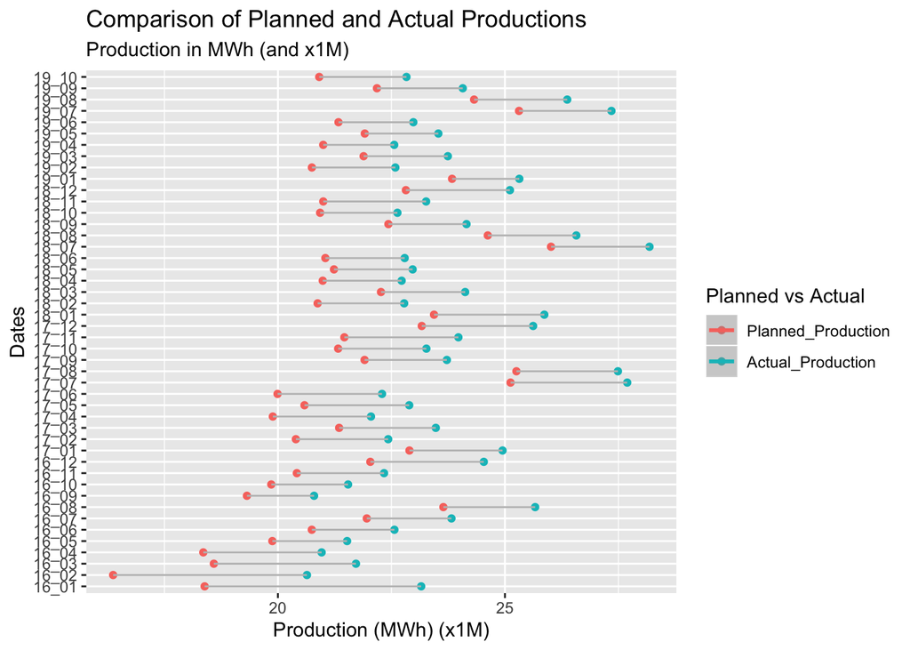

```r
library(ggplot2)
library(reshape2)
G_CompPlanProd <- melt(CompPlanProd, id.vars="Dates")

ggplot(G_CompPlanProd, aes(value/1000000, Dates, col=variable)) +
  geom_point() +
  stat_smooth() +
  geom_line( color="grey") +
labs(title="Comparison of Planned and Actual Productions",
       subtitle="Production in MWh (and x1M)",
     x="Production (MWh) (x1M)",
     y="Dates",
     col="Planned vs Actual")
```

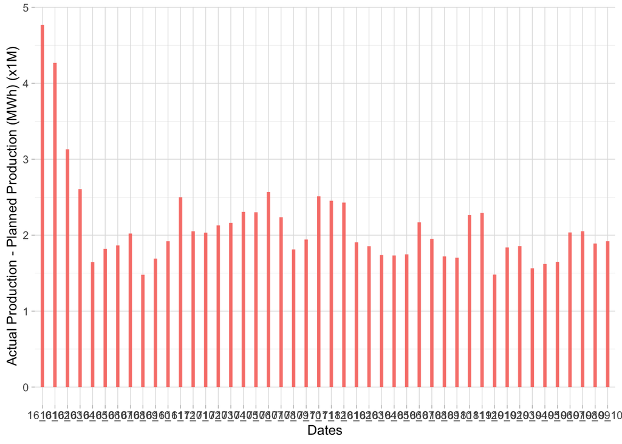

```r
CompPlanProd_2<-data.frame(CompPlanProd)
CompPlanProd_2$Difference <- (CompPlanProd_2$Actual_Production - CompPlanProd_2$Planned_Production)/1000000
CompPlanProdDiff <- CompPlanProd_2 %>% select(Dates, Difference)

CompPlanProdDiff <- CompPlanProdDiff %>%
  mutate(mycolor = ifelse(CompPlanProdDiff$Difference>0, "type1", "type2"))

ggplot(CompPlanProdDiff, aes(x=CompPlanProdDiff$Dates, y=CompPlanProdDiff$Difference)) +
  geom_segment( aes(x=CompPlanProdDiff$Dates, xend=CompPlanProdDiff$Dates, y=0, yend=CompPlanProdDiff$Difference, color=mycolor), size=1.3, alpha=0.9) +
  theme_light() +
  theme(
    legend.position = "none",
    panel.border = element_blank(),
  ) +
  xlab("Dates") +
  ylab("Actual Production - Planned Production (MWh) (x1M)")
```

### Comparison of Planned Production (MWh) and Actual Production (MWh) for Sources

```r
Production_Monthly_Trp <- as.data.frame(transpose(Production_Monthly))
colnames(Production_Monthly_Trp) <- c('toplam_mwh', 'dogal_gaz',    'barajli',  'linyit',   'akarsu',   'ithal_komur',  'ruzgar',   'gunes',    'fuel_oil', 'jeotermal',    'asfaltit_komur',   'tas_komur',    'biyokutle',    'nafta',    'lng',  'uluslararasi')
Production_Monthly_Trp[] <- lapply(Production_Monthly_Trp, function(x) as.numeric(as.character(x)))
Production_Monthly_Trp$Dates <-  c('Sources', '16_01', '16_02', '16_03', '16_04', '16_05', '16_06', '16_07', '16_08', '16_09', '16_10', '16_11', '16_12', '17_01', '17_02', '17_03', '17_04', '17_05', '17_06', '17_07', '17_08', '17_09', '17_10', '17_11', '17_12', '18_01', '18_02', '18_03', '18_04', '18_05', '18_06', '18_07', '18_08', '18_09', '18_10', '18_11', '18_12', '19_01', '19_02', '19_03', '19_04', '19_05', '19_06', '19_07', '19_08', '19_09', '19_10')
Production_Monthly_Trp <- Production_Monthly_Trp[-1,]
Production_Monthly_Trp <- Production_Monthly_Trp[,-1]

head(Production_Monthly_Trp,5)
```

```
##   dogal_gaz barajli  linyit  akarsu ithal_komur    ruzgar gunes fuel_oil
## 2   8093942 4249679 3401925 1271297     3728569 1256556.7     0 153842.2
## 3   6851969 3283233 3112894 1815672     3441797 1136751.9     0 131466.9
## 4   6278424 4260896 3066094 2480136     3252120 1248335.7     0 155338.7
## 5   6733069 4288169 2359898 2680860     2999844  816274.5     0 159601.7
## 6   6033318 4077205 2775400 2578332     4035879  923452.2     0 156074.2
##   jeotermal asfaltit_komur tas_komur biyokutle nafta     lng uluslararasi
## 2  351444.9       271455.7  249304.5  120657.8     0 6398.32            0
## 3  327393.8       223096.4  191865.0  117012.6     0 6227.85            0
## 4  357303.4       253712.2  232404.0  127375.7     0 6539.90            0
## 5  332710.6       226864.7  236477.0  122834.8     0 5909.81            0
## 6  347485.5       252689.2  211254.5  125607.5     0 6533.56            0
##   Dates
## 2 16_01
## 3 16_02
## 4 16_03
## 5 16_04
## 6 16_05
```

```r
Planning_Monthly_Trp <- as.data.frame(transpose(Planning_Monthly))
colnames(Planning_Monthly_Trp) <- c('toplam_mwh',   'dogal_gaz',    'ruzgar',   'linyit',   'tas_komur',    'ithal_komur', 'fuel_oil', 'jeotermal', 'barajli',  'nafta', 'biyokutle',   'akarsu',   'diger')
Planning_Monthly_Trp[] <- lapply(Planning_Monthly_Trp, function(x) as.numeric(as.character(x)))
Planning_Monthly_Trp$Dates <-  c('Sources', '16_01', '16_02', '16_03', '16_04', '16_05', '16_06', '16_07', '16_08', '16_09', '16_10', '16_11', '16_12', '17_01', '17_02', '17_03', '17_04', '17_05', '17_06', '17_07', '17_08', '17_09', '17_10', '17_11', '17_12', '18_01', '18_02', '18_03', '18_04', '18_05', '18_06', '18_07', '18_08', '18_09', '18_10', '18_11', '18_12', '19_01', '19_02', '19_03', '19_04', '19_05', '19_06', '19_07', '19_08', '19_09', '19_10')
Planning_Monthly_Trp <- Planning_Monthly_Trp[-1,]
Planning_Monthly_Trp <- Planning_Monthly_Trp[,-1]

head(Planning_Monthly_Trp,5)
```

```
##   dogal_gaz    ruzgar  linyit tas_komur ithal_komur fuel_oil jeotermal
## 2   6956584  97156.52 2785761    553672     3326572 415328.6  45185.60
## 3   5751947 125460.91 2562705    530251     3121218 522803.0  23687.55
## 4   5427182 618063.48 2419857    630380     2930062 266379.0 195261.82
## 5   6086039 487208.62 1794658    554156     2599052  92350.7 194474.33
## 6   5080387 705477.80 2189356    575697     3544970  90112.0 288480.61
##   barajli  nafta biyokutle    akarsu    diger Dates
## 2 3770299 3456.0    267.00  189367.4 242055.7 16_01
## 3 3146464 3124.3   1811.90  354320.6 226544.1 16_02
## 4 4574145 3393.7  31748.90 1251710.1 240048.0 16_03
## 5 4780549 3200.2  38345.52 1515080.7 210968.4 16_04
## 6 4940352 3263.0  56677.03 2168194.0 234186.8 16_05
```

```r
PlanProdSources <- as.data.frame(c(1:46))
PlanProdSources$Dates <- Planning_Monthly_Trp$Dates
PlanProdSources$Barajlı <- (Production_Monthly_Trp$barajli - Planning_Monthly_Trp$barajli)
PlanProdSources$Linyit <- (Production_Monthly_Trp$linyit - Planning_Monthly_Trp$linyit)
PlanProdSources$Akarsu <- (Production_Monthly_Trp$akarsu - Planning_Monthly_Trp$akarsu)
PlanProdSources$Ithal_Komur <- (Production_Monthly_Trp$ithal_komur - Planning_Monthly_Trp$ithal_komur)
PlanProdSources$Ruzgar <- (Production_Monthly_Trp$ruzgar - Planning_Monthly_Trp$ruzgar)
PlanProdSources$Fuel_Oil <- (Production_Monthly_Trp$fuel_oil - Planning_Monthly_Trp$fuel_oil)
PlanProdSources$Jeotermal <- (Production_Monthly_Trp$jeotermal - Planning_Monthly_Trp$jeotermal)
PlanProdSources$Taskomur <- (Production_Monthly_Trp$tas_komur - Planning_Monthly_Trp$tas_komur)
PlanProdSources$Biyokutle <- (Production_Monthly_Trp$biyokutle - Planning_Monthly_Trp$biyokutle)
PlanProdSources <- PlanProdSources[,-1]

head(PlanProdSources,5)
```

```
##   Dates   Barajlı   Linyit    Akarsu Ithal_Komur    Ruzgar   Fuel_Oil
## 1 16_01  479380.2 616163.6 1081929.4    401996.9 1159400.2 -261486.43
## 2 16_02  136768.4 550189.7 1461351.4    320578.6 1011291.0 -391336.07
## 3 16_03 -313248.2 646237.0 1228425.6    322058.1  630272.2 -111040.33
## 4 16_04 -492380.7 565239.7 1165779.3    400791.9  329065.9   67250.98
## 5 16_05 -863147.0 586044.8  410138.1    490908.7  217974.4   65962.16
##   Jeotermal  Taskomur Biyokutle
## 1 306259.34 -304367.5 120390.76
## 2 303706.25 -338386.0 115200.66
## 3 162041.57 -397976.0  95626.83
## 4 138236.29 -317679.0  84489.25
## 5  59004.85 -364442.5  68930.46
```

When the differences between actual production and planned production values are analyzed by source; It is seen that there are no significant differences between the two values in Geothermal, Biomass, Fuel Oil sources, but there are differences between plan and production in sources such as Dams, Stream and Lignite.

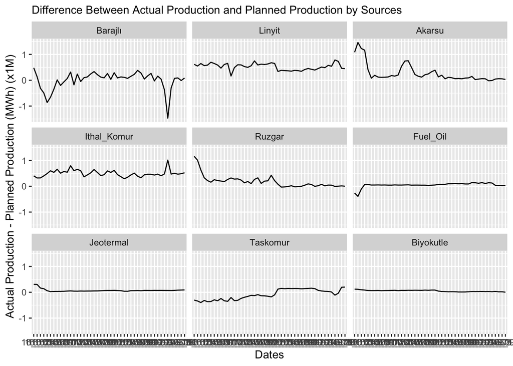

```r
library(ggplot2)
library(reshape2)
G_PlanProdSources <- melt(PlanProdSources, id.vars="Dates")
colnames(G_PlanProdSources) <- c('Dates',   'Source',   'Prod_Plan_Difference')
ggplot(data = G_PlanProdSources, aes(x = Dates , y = Prod_Plan_Difference/1000000, group = 1)) +
    geom_line() +
    facet_wrap(~ Source) +
    labs(subtitle = "Difference Between Actual Production and Planned Production by Sources", y="Actual Production - Planned Production (MWh) (x1M)", x="Dates")
```

## Comparison of Production and Consumption

When real production and consumption values are compared, it is seen that consumption values are higher than production values. In the 46-month period from the beginning of 2016 to October 2019, it was found that only 6 months (listed below) Production value was higher than Consumption value and consumption was higher than production in all remaining months;

- March 2016
- April 2017
- May 2017
- October 2017
- November 2017
- December 2017

```r
Con_MT <- subset(Consumption_Monthly, Sources=="tuketim_miktari_mwh")
Con_MT <- as.data.frame(transpose(Con_MT))
CompProdCon <- cbind(Prod_MT, Con_MT)
colnames(CompProdCon) <- c('Actual_Production', 'Consumption')
CompProdCon <- CompProdCon[-1,]
CompProdCon$Dates <-  c('16_01', '16_02', '16_03', '16_04', '16_05', '16_06', '16_07', '16_08', '16_09', '16_10', '16_11', '16_12', '17_01', '17_02', '17_03', '17_04', '17_05', '17_06', '17_07', '17_08', '17_09', '17_10', '17_11', '17_12', '18_01', '18_02', '18_03', '18_04', '18_05', '18_06', '18_07', '18_08', '18_09', '18_10', '18_11', '18_12', '19_01', '19_02', '19_03', '19_04', '19_05', '19_06', '19_07', '19_08', '19_09', '19_10')
CompProdCon$Actual_Production <-as.numeric(CompProdCon$Actual_Production)
CompProdCon$Consumption <-as.numeric(CompProdCon$Consumption)

head(CompProdCon,5)
```

```
##   Actual_Production Consumption Dates
## 2          23155072    23704522 16_01
## 3          20639380    21153165 16_02
## 4          21718680    21535377 16_03
## 5          20962513    21301824 16_04
## 6          21523232    21900302 16_05
```

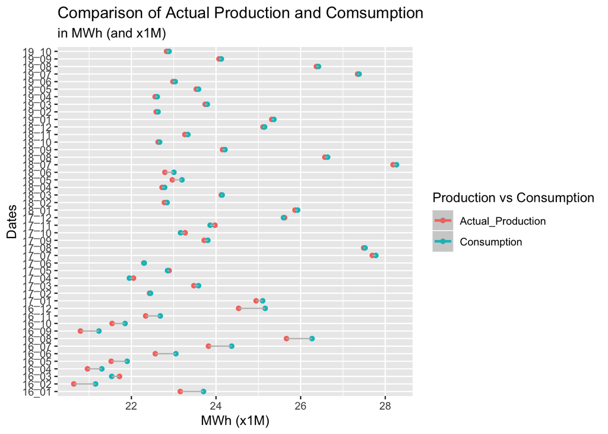

```r
library(ggplot2)
library(reshape2)
G_CompProdCon <- melt(CompProdCon, id.vars="Dates")

ggplot(G_CompProdCon, aes(value/1000000, Dates, col=variable)) +
  geom_point() +
  stat_smooth() +
  geom_line( color="grey") +
labs(title="Comparison of Actual Production and Comsumption",
       subtitle="in MWh (and x1M)",
     x="MWh (x1M)",
     y="Dates",
     col="Production vs Consumption")
```

```r
CompProdCon_2<-data.frame(CompProdCon)
CompProdCon_2$Difference <- (CompProdCon_2$Actual_Production - CompProdCon_2$Consumption)/1000000
CompProdConDiff <- CompProdCon_2 %>% select(Dates, Difference)

head(CompProdConDiff, 5)
```

```
##   Dates Difference
## 2 16_01 -0.5494502
## 3 16_02 -0.5137849
## 4 16_03  0.1833031
## 5 16_04 -0.3393110
## 6 16_05 -0.3770707
```

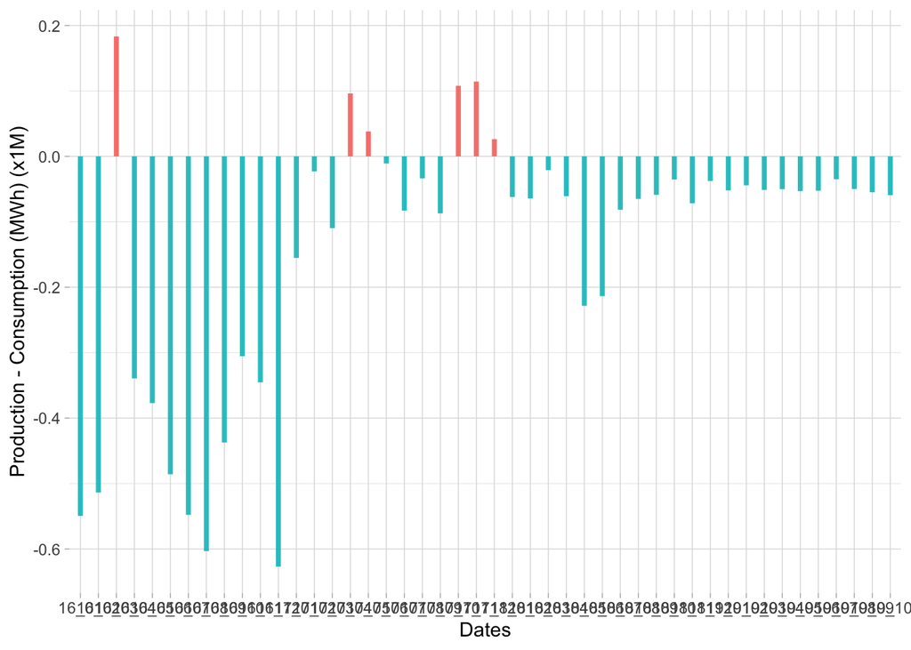

```r
CompProdConDiff <- CompProdConDiff %>%
  mutate(mycolor = ifelse(CompProdConDiff$Difference>0, "type1", "type2"))

ggplot(CompProdConDiff, aes(x=CompProdConDiff$Dates, y=CompProdConDiff$Difference)) +
  geom_segment( aes(x=CompProdConDiff$Dates, xend=CompProdConDiff$Dates, y=0, yend=CompProdConDiff$Difference, color=mycolor), size=1.3, alpha=0.9) +
  theme_light() +
  theme(
    legend.position = "none",
    panel.border = element_blank(),
  ) +
  xlab("Dates") +
  ylab("Production - Consumption (MWh) (x1M)")
```